# DTW 알고리즘 군집화

### DTW 이용한 군집화

```python
# 군집 4개 일 때 모델
clutser_model = model[1]
```

```python
# 군집 4개 일 때 결과
result[1]
```

```
array([0, 0, 1, 0, 0, 0, 3, 2, 3, 0, 0, 2, 0, 0, 3, 2, 3, 3, 1, 3, 3, 0,
       2, 0, 0, 0, 1, 3, 3, 1, 3, 0, 0, 3, 3, 2, 3], dtype=int64)
```

```python
cluster_df = pd.DataFrame(index=평가데이터1.columns,columns=["label"])
cluster_df["label"] = result[1]
```

```python
cluster_df
```

|  | label |
| --- | --- |
| 건입동 | 0 |
| 남원읍 | 0 |
| 노형동 | 1 |
| 대륜동 | 0 |
| 대정읍 | 0 |
| 대천동 | 0 |
| 도두동 | 3 |
| 동홍동 | 2 |
| 봉개동 | 3 |
| 삼도1동 | 0 |
| 삼도2동 | 0 |
| 삼양동 | 2 |
| 서홍동 | 0 |
| 성산읍 | 0 |
| 송산동 | 3 |
| 아라동 | 2 |
| 안덕면 | 3 |
| 애월읍 | 3 |
| 연동 | 1 |
| 영천동 | 3 |
| 예래동 | 3 |
| 오라동 | 0 |
| 외도동 | 2 |
| 용담1동 | 0 |
| 용담2동 | 0 |
| 이도1동 | 0 |
| 이도2동 | 1 |
| 이호동 | 3 |
| 일도1동 | 3 |
| 일도2동 | 1 |
| 정방동 | 3 |
| 중문동 | 0 |
| 중앙동 | 0 |
| 천지동 | 3 |
| 표선면 | 3 |
| 화북동 | 2 |
| 효돈동 | 3 |

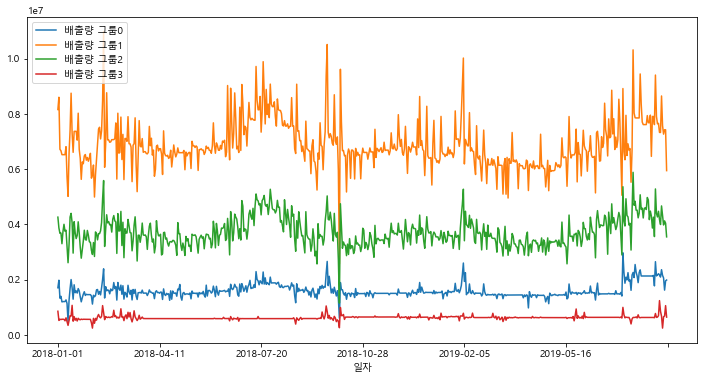

```python
# 4개 군집의 중심점 시각화 해보기
fig,ax = plt.subplots(1,1,figsize=(12,6))
for i in range(4):
    df = pd.DataFrame(index = 평가데이터1.index,columns=["배출량"],
                      data = clutser_model.cluster_centers_[i])

    # 군집 중심점으로 그래프 그리기
    (df.iloc[:,0]).plot(ax = ax,label="배출량 그룹" +str(i))
    ax.legend()
```

군집 각각 시각화

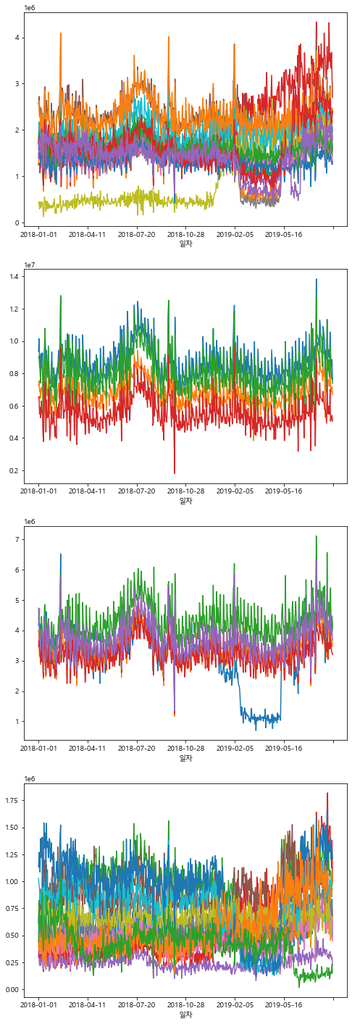

```python
fig,ax = plt.subplots(4,1,figsize=(8,25))
for j in range(4):

    # 군집 0번부터 3번까지
    for i in cluster_df[cluster_df['label'] == j].index:

        평가데이터1[i].plot(ax=ax[j])
```

# 왜도 처리방식

- 데이터가 조금 더 균등한 분포를 가질 수 있도록 log 변환

스마트팜 데이터 가져오기

```python
org_data = pd.read_csv("smart_farm_final.csv").sample(n = 10000)
org_data.shape
```

```
(10000, 57)
```

```python
org_data.head(3)
```

|  | 시간 | 년도 | 월 | 일 | 시 | 분 | 일사량(W/㎡) | 외기온(℃) | 외기습도(%) | 풍속(m/s) | ... | 하루길이 | 시간범주 | 일몰전후 | 일출일몰 | 지면온도 | 오존등급 | 아황산가스등급 | 이산화질소등급 | PM10등급 | PM25등급 |
| --- | --- | --- | --- | --- | --- | --- | --- | --- | --- | --- | --- | --- | --- | --- | --- | --- | --- | --- | --- | --- | --- |
| 44039 | 2021-12-29 20:44:00 | 2021 | 12 | 29 | 20 | 44 | 0.0 | 3.7 | 60 | 1.8 | ... | 949 | 야간 | 일몰1시간반_후 | 일몰 | 1.5 | 보통 | 좋음 | 좋음 | 보통 | 보통 |
| 136678 | 2022-03-09 00:30:00 | 2022 | 3 | 9 | 0 | 30 | 0.0 | 1.6 | 64 | 0.4 | ... | 1143 | 야간 | 일몰1시간반_후 | 일몰 | -1.5 | 보통 | 좋음 | 좋음 | 보통 | 나쁨 |
| 73485 | 2022-01-20 11:10:00 | 2022 | 1 | 20 | 11 | 10 | 556.0 | 1.3 | 39 | 1.8 | ... | 1009 | 주간 | 일몰1시간반_전 | 일출 | 0.9 | 보통 | 좋음 | 좋음 | 좋음 | 보통 |

3 rows × 57 columns

왜도가 3이 넘는 데이터가 있는지 확인

```python
loglist=[]
# 왜도 3인 설명변수 log1p 변환
for val in ['일사량(W/㎡)','외기온(℃)','외기습도(%)','풍속(m/s)', '풍향(º)','내부 온도','내부 습도','차광스크린(수평)','차열스크린(수평)',
 '에너지스크린(수평)','에너지스크린(수직)','천창','난방온도(설정온도)','누적강수량','현지기압','해면기압','PM10_1시간','PM25_1시간',
 '오존_1시간','이산화질소_1시간','일산화탄소_1시간','아황산가스_1시간','지면온도',"열공급량(kWh)"]:
    if abs(org_data[val].skew())>3:
        print(val,"의 왜도 값은 : ",abs(org_data[val].skew()))
        loglist.append(val)
        print("----- 구분선 -----")

loglist
```

```
천창 의 왜도 값은 :  4.755060518624134
----- 구분선 -----
누적강수량 의 왜도 값은 :  7.492818388018969
----- 구분선 -----
아황산가스_1시간 의 왜도 값은 :  3.2193027226322837
----- 구분선 -----
```

```
['천창', '누적강수량', '아황산가스_1시간']
```

시각화해서 확인하기

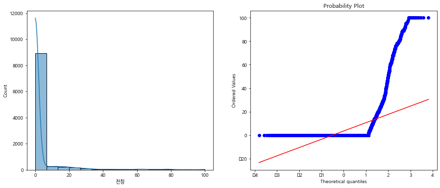

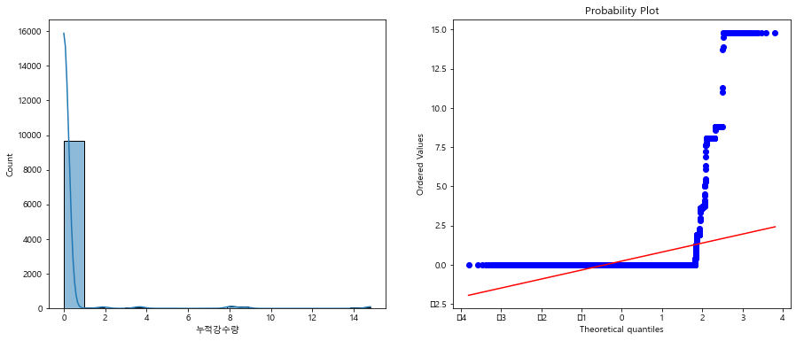

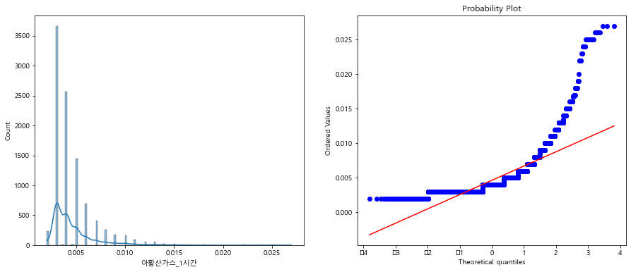

```python
from scipy import stats
for col in ['천창', '누적강수량', '아황산가스_1시간']:
    fig, axs = plt.subplots(1,2, figsize = (15,6))
    sns.histplot(org_data[col], ax =axs[0], kde=True)
    stats.probplot(org_data[col], dist='norm', fit=True, plot=axs[1])

plt.show()
```

특정 데이터에 대해서 로그변환 적용

- 아황산가스_1시간 데이터

```
log1p 변환이전 :  3.2193027226322837
log1p 변환이후 :  3.162377130503439
```

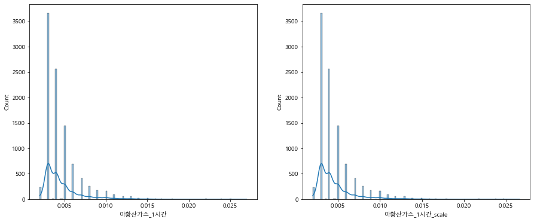

```python
val = "아황산가스_1시간"

fig, axs = plt.subplots(1,2, figsize = (15,6))

sns.histplot(org_data[val], ax =axs[0], kde=True)

# 왜도 3인 독립변수 log1p 변환
print("log1p 변환이전 : ",abs(org_data[val].skew()))
org_data[val+"_scale"] = np.log1p(org_data[val])

sns.histplot(org_data[val+"_scale"], ax =axs[1], kde=True)

print("log1p 변환이후 : ",abs(np.log1p(org_data[val+"_scale"]).skew()))

plt.show()
```

# 이상치 처리 방식

- Z score 3 넘는 값을 Z score 3으로 대체

```python
def replace_outlier_zscore(df,columns,n):
    data = df.copy()
    mean = np.mean(data[columns])
    std = np.std(data[columns])
    score_top = int(n)*std + mean
    score_bot = -1*n*std + mean

    def cond1(x):
        if x > score_top:
            return score_top
        if x < score_bot:
            return score_bot
        else:
            return x
    data[columns] = data[columns].apply(cond1)

    return data[columns]
```

```python
for col in ['일사량(W/㎡)','외기온(℃)','외기습도(%)','풍속(m/s)', '풍향(º)','내부 온도','내부 습도','차광스크린(수평)','차열스크린(수평)',
 '에너지스크린(수평)','에너지스크린(수직)','난방온도(설정온도)','누적강수량','현지기압','해면기압','PM10_1시간','PM25_1시간',
 '오존_1시간','이산화질소_1시간','일산화탄소_1시간','아황산가스_1시간','지면온도']:

    org_data[col+"_scale"] = replace_outlier_zscore(org_data,col,3)

    if (org_data[col] == org_data[col+"_scale"]).sum() == 10000:
        pass

    else:
        print(col)
        print("개수 : ",10000 - (org_data[col] == org_data[col+"_scale"]).sum())

    #org_data.drop([col+"_scale"],axis=1,inplace=True)
```

```
일사량(W/㎡)
개수 :  34
외기온(℃)
개수 :  24
풍속(m/s)
개수 :  150
내부 온도
개수 :  10
내부 습도
개수 :  96
누적강수량
개수 :  195
현지기압
개수 :  67
해면기압
개수 :  64
PM10_1시간
개수 :  159
PM25_1시간
개수 :  145
오존_1시간
개수 :  23
이산화질소_1시간
개수 :  44
일산화탄소_1시간
개수 :  155
아황산가스_1시간
개수 :  186
지면온도
개수 :  232
```

```python
org_data
```

|  | 시간 | 년도 | 월 | 일 | 시 | 분 | 일사량(W/㎡) | 외기온(℃) | 외기습도(%) | 풍속(m/s) | ... | 난방온도(설정온도)_scale | 누적강수량_scale | 현지기압_scale | 해면기압_scale | PM10_1시간_scale | PM25_1시간_scale | 오존_1시간_scale | 이산화질소_1시간_scale | 일산화탄소_1시간_scale | 지면온도_scale |
| --- | --- | --- | --- | --- | --- | --- | --- | --- | --- | --- | --- | --- | --- | --- | --- | --- | --- | --- | --- | --- | --- |
| 44039 | 2021-12-29 20:44:00 | 2021 | 12 | 29 | 20 | 44 | 0.0 | 3.7 | 60 | 1.8 | ... | 15.8 | 0.0 | 1016.0 | 1019.6 | 39.0 | 31.0 | 0.033 | 0.019 | 0.5 | 1.5 |
| 136678 | 2022-03-09 00:30:00 | 2022 | 3 | 9 | 0 | 30 | 0.0 | 1.6 | 64 | 0.4 | ... | 18.0 | 0.0 | 1015.5 | 1019.2 | 65.0 | 42.0 | 0.032 | 0.027 | 0.5 | -1.5 |
| 73485 | 2022-01-20 11:10:00 | 2022 | 1 | 20 | 11 | 10 | 556.0 | 1.3 | 39 | 1.8 | ... | 20.0 | 0.0 | 1024.6 | 1028.3 | 22.0 | 17.0 | 0.032 | 0.010 | 0.4 | 0.9 |
| 41435 | 2021-12-28 01:18:00 | 2021 | 12 | 28 | 1 | 18 | 0.0 | -3.3 | 74 | 0.4 | ... | 18.0 | 0.0 | 1026.0 | 1029.8 | 18.0 | 12.0 | 0.013 | 0.017 | 0.4 | -1.7 |
| 132209 | 2022-03-05 22:01:00 | 2022 | 3 | 5 | 22 | 1 | 0.0 | 2.9 | 32 | 1.8 | ... | 16.1 | 0.0 | 1015.2 | 1018.9 | 20.0 | 9.0 | 0.045 | 0.006 | 0.3 | 0.0 |
| ... | ... | ... | ... | ... | ... | ... | ... | ... | ... | ... | ... | ... | ... | ... | ... | ... | ... | ... | ... | ... | ... |
| 52982 | 2022-01-06 03:29:00 | 2022 | 1 | 6 | 3 | 29 | 0.0 | 3.3 | 55 | 0.0 | ... | 18.0 | 0.0 | 1021.0 | 1024.7 | 27.0 | 19.0 | 0.014 | 0.017 | 0.4 | 1.7 |
| 116458 | 2022-02-19 16:24:00 | 2022 | 2 | 19 | 16 | 24 | 198.0 | 7.5 | 26 | 5.8 | ... | 20.0 | 0.0 | 1015.6 | 1019.2 | 15.0 | 10.0 | 0.047 | 0.009 | 0.4 | 11.6 |
| 2243 | 2021-11-27 14:44:00 | 2021 | 11 | 27 | 14 | 44 | 398.0 | 12.5 | 29 | 1.3 | ... | 20.0 | 0.0 | 1029.0 | 1032.6 | 13.0 | 10.0 | 0.042 | 0.007 | 0.3 | 15.5 |
| 43240 | 2021-12-29 07:25:00 | 2021 | 12 | 29 | 7 | 25 | 0.0 | -2.9 | 85 | 0.4 | ... | 19.6 | 0.0 | 1019.2 | 1023.0 | 36.0 | 32.0 | 0.002 | 0.029 | 0.6 | -1.0 |
| 62125 | 2022-01-12 12:11:00 | 2022 | 1 | 12 | 12 | 11 | 608.0 | 1.9 | 28 | 1.8 | ... | 20.0 | 0.0 | 1017.6 | 1021.3 | 16.0 | 12.0 | 0.033 | 0.010 | 0.3 | 2.4 |

10000 rows × 79 columns

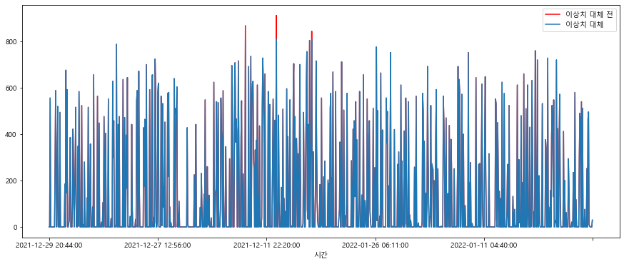

```python
fig, axs = plt.subplots(1,1, figsize = (15,6))
org_data.iloc[:1000,:].set_index("시간")["일사량(W/㎡)"].plot(ax=axs,color="red",label="이상치 대체 전")
org_data.iloc[:1000,:].set_index("시간")["일사량(W/㎡)_scale"].plot(ax=axs,label = "이상치 대체")
plt.legend()
```

# KFold와 Stratified Kfold

- 교차검증

```python
from sklearn.datasets import load_iris
import pandas as pd
import numpy as np

# 데이터셋 로드
iris = load_iris()
df = pd.DataFrame(data= np.c_[iris.data, iris.target] ,
                  columns= ['sepal length', 'sepal width', 'petal length', 'petal width', 'label'])

df
```

|  | sepal length | sepal width | petal length | petal width | label |
| --- | --- | --- | --- | --- | --- |
| 0 | 5.1 | 3.5 | 1.4 | 0.2 | 0.0 |
| 1 | 4.9 | 3.0 | 1.4 | 0.2 | 0.0 |
| 2 | 4.7 | 3.2 | 1.3 | 0.2 | 0.0 |
| 3 | 4.6 | 3.1 | 1.5 | 0.2 | 0.0 |
| 4 | 5.0 | 3.6 | 1.4 | 0.2 | 0.0 |
| ... | ... | ... | ... | ... | ... |
| 145 | 6.7 | 3.0 | 5.2 | 2.3 | 2.0 |
| 146 | 6.3 | 2.5 | 5.0 | 1.9 | 2.0 |
| 147 | 6.5 | 3.0 | 5.2 | 2.0 | 2.0 |
| 148 | 6.2 | 3.4 | 5.4 | 2.3 | 2.0 |
| 149 | 5.9 | 3.0 | 5.1 | 1.8 | 2.0 |

150 rows × 5 columns

- n_splits : 분할할 세트의 개수, 1세트만 test 데이터로 사용하고 나머지는 train 데이터로 사용
- shuffle : True로 설정 시 데이터셋 내의 순서를 섞어서 샘플링, False인 경우 순서대로 분할
- random_state : 난수 설정, 특정 정수로 지정 시 샘플링 결과 고정

```python
from sklearn.model_selection import KFold
from sklearn.ensemble import RandomForestClassifier
from sklearn.metrics import accuracy_score

accuracy_history = []

X = np.array(df.iloc[:, :-1]) # label 열 제외한 feature 열들 모음 -> array 변환
y = df['label'] # label 부분

# split 개수, 셔플 여부 및 seed 설정
kf = KFold(n_splits = 5, shuffle = True, random_state = 0)

# split 개수 스텝 만큼 train, test 데이터셋을 매번 분할
for train_index, test_index in kf.split(X):
    X_train, X_test = X[train_index], X[test_index]
    y_train, y_test = y[train_index], y[test_index]

    model = RandomForestClassifier(n_estimators=5, random_state=0) # 모델 선언
    model.fit(X_train, y_train) # 모델 학습

    y_pred = model.predict(X_test) # 예측 라벨
    accuracy_history.append(accuracy_score(y_pred, y_test)) # 정확도 측정 및 기록

print("각 분할의 정확도 기록 :", accuracy_history)
print("평균 정확도 :", np.mean(accuracy_history))
```

```
각 분할의 정확도 기록 : [0.9666666666666667, 0.8666666666666667, 1.0, 1.0, 0.9]
평균 정확도 : 0.9466666666666667
```

```python
print("학습 데이터개수 ",len(train_index))
print("검증 데이터개수 ",len(test_index))
```

```
학습 데이터개수  120
검증 데이터개수  30
```

#### Stratified KFold

- 교차 검증 시 주의해야할 사항으로 train/test 셋에서 각 클래스의 비율이 동일하게 분포해야한다는 점

```python
from sklearn.model_selection import StratifiedKFold

# split 개수, 셔플 여부 및 seed 설정
str_kf = StratifiedKFold(n_splits = 5, shuffle = True, random_state = 50)

# split 개수 스텝 만큼 train, test 데이터셋을 매번 분할
for train_index, test_index in str_kf.split(X, y):
    X_train, X_test = X[train_index], X[test_index]
    y_train, y_test = y[train_index], y[test_index]

    model = RandomForestClassifier(n_estimators=5, random_state=0) # 모델 선언
    model.fit(X_train, y_train) # 모델 학습

    y_pred = model.predict(X_test) # 예측 라벨
    accuracy_history.append(accuracy_score(y_pred, y_test)) # 정확도 측정 및 기록

print("각 분할의 정확도 기록 :", accuracy_history)
print("평균 정확도 :", np.mean(accuracy_history))
```

```
각 분할의 정확도 기록 : [0.9666666666666667, 0.8666666666666667, 1.0, 1.0, 0.9, 0.9666666666666667, 0.8666666666666667, 1.0, 1.0, 0.9, 0.9333333333333333, 0.9666666666666667, 1.0, 0.9666666666666667, 0.9333333333333333]
평균 정확도 : 0.9511111111111111
```